# Survey Data Report

April 08, 2020

# Data Summary Report for Idaho

#### As of 2020-04-08 16:54:35 there have been 10 intervention updates reported for Idaho. These entries were logged by no name provided. These updates represent the following intervention sections:

| Included Interventions |
| --- |
| School closures |
| Household confinement |
| Office closures |
| Retail store closures (excluding essentials) |
| Limiting size of gatherings |
| State of emergency |
| Restaurant closures and limitations |
| Quarantine and home isolation |

Please review the following updates for each intervention and confirm that the information is correct.

#### To report any corrections that have not already been logged on GitHub please use this [form](https://forms.gle/S4JEgrxjy4YKPBMo8).

In particular as shown in the following table and highlighted through the rest of the report:

- There are 0 entries where the date of the intervention update is after the date of entry. **Please confirm that these dates are correct.**
- There are 0 entries where the invervention status indicates a relaxing of restrictions before mid April. Note that for limits on social gatherings a status of “no” means there is no limit on social gatherings and for household confinment a status of “unrestricted” means the lifting of a stay at home or shelter in place order. **Please confirm that these statuses are correct.**
- There are 0 entries where the intervention status is “unknown”. **Please provide the correct status and date.**
- There are 0 entries that may be duplicates. **Please confirm that these are unique updates.**

## School closures

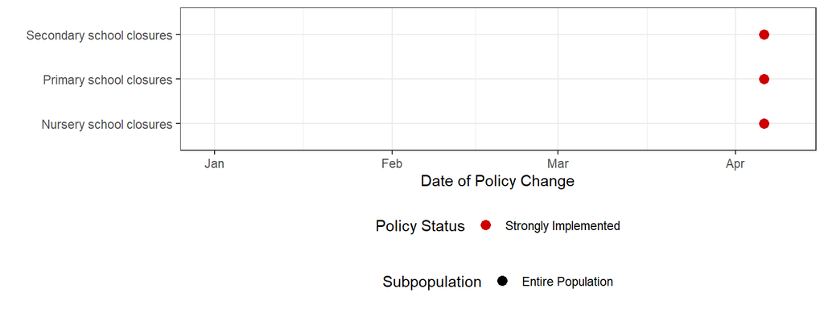

|  | record_id | entry_date | intervention_specific_clean | date_of_update | status | subpopulation | required | details | any_flag |
| --- | --- | --- | --- | --- | --- | --- | --- | --- | --- |
| 1 | 724 | 2020-04-07 | Nursery school closures | 2020-04-06 | closed | entire population | required | closed for the rest of the year, but appears that individual districts can decide to reopen only in newsdo not see this from state | False |
| 2 | 724 | 2020-04-07 | Primary school closures | 2020-04-06 | closed | entire population | required | extended school closures to end of the school year | False |
| 3 | 724 | 2020-04-07 | Secondary school closures | 2020-04-06 | closed | entire population | required | extended school closures to end of the school year | False |

## Household confinement

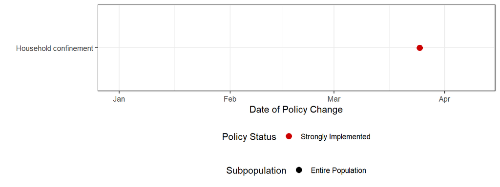

|  | record_id | entry_date | intervention_specific_clean | date_of_update | status | subpopulation | required | enforcement | any_flag |
| --- | --- | --- | --- | --- | --- | --- | --- | --- | --- |
| 1 | 724 | 2020-04-07 | Household confinement | 2020-03-25 | fully restricted | entire population | required | No | False |

## Office closures

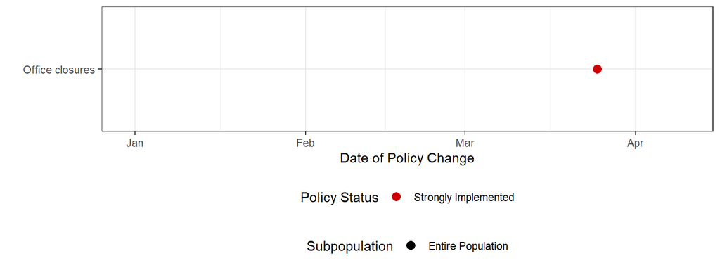

|  | record_id | entry_date | intervention_specific_clean | date_of_update | status | subpopulation | required | any_flag |
| --- | --- | --- | --- | --- | --- | --- | --- | --- |
| 1 | 724 | 2020-04-07 | Office closures | 2020-03-25 | closed | entire population | required | False |

## Retail store closures (excluding essentials)

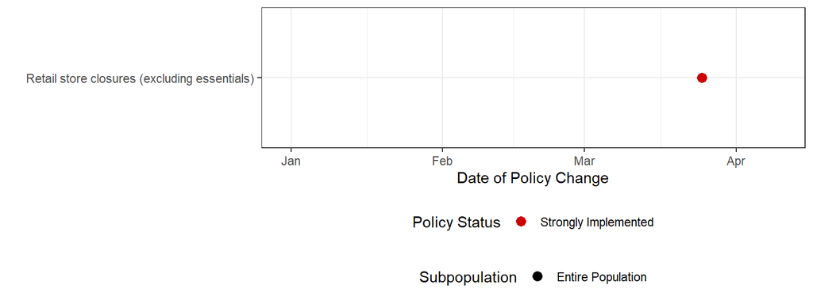

|  | record_id | entry_date | intervention_specific_clean | date_of_update | status | subpopulation | required | any_flag |
| --- | --- | --- | --- | --- | --- | --- | --- | --- |
| 1 | 724 | 2020-04-07 | Retail store closures (excluding essentials) | 2020-03-25 | closed | entire population | required | False |

## Limiting size of gatherings

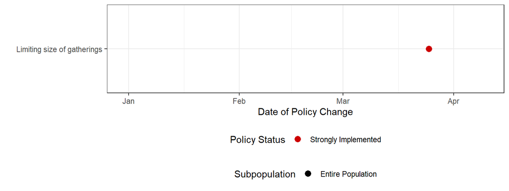

|  | record_id | entry_date | intervention_specific_clean | date_of_update | status | subpopulation | required | size | details | any_flag |
| --- | --- | --- | --- | --- | --- | --- | --- | --- | --- | --- |
| 1 | 724 | 2020-04-07 | Limiting size of gatherings | 2020-03-25 | required | entire population | required | 0 | no gatherings allowed outside the homes | False |

## State of emergency

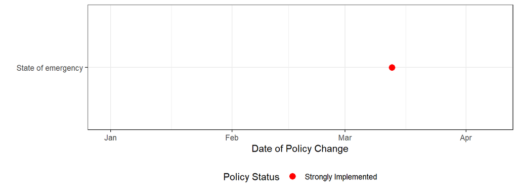

|  | record_id | entry_date | intervention_specific_clean | date_of_update | status | any_flag |
| --- | --- | --- | --- | --- | --- | --- |
| 1 | 724 | 2020-04-07 | State of emergency | 2020-03-13 | yes | False |

## Restaurant closures and limitations

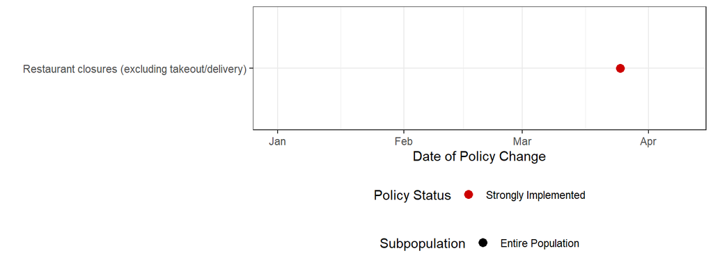

|  | record_id | entry_date | intervention_specific_clean | date_of_update | status | subpopulation | required | any_flag |
| --- | --- | --- | --- | --- | --- | --- | --- | --- |
| 1 | 724 | 2020-04-07 | Restaurant closures (excluding takeout/delivery) | 2020-03-25 | closed | entire population | required | False |

## Quarantine and home isolation

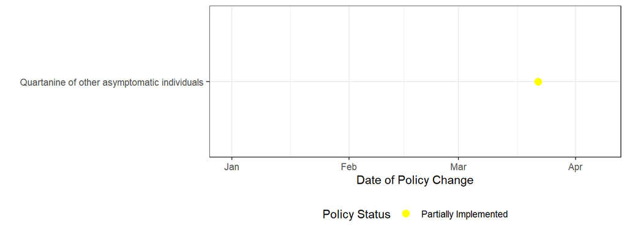

|  | record_id | entry_date | intervention_specific_clean | date_of_update | status | required | any_flag |
| --- | --- | --- | --- | --- | --- | --- | --- |
| 1 | 724 | 2020-04-07 | Quartanine of other asymptomatic individuals | 2020-03-22 | recommended | recommended | False |

#### There were no entries for the following interventions. **Please confirm that there have been no updates for these intervention sections.**

| Missing Interventions |
| --- |
| Limiting movement within borders |
| Nursing home/long-term care closures |
| Leisure, entertainment, and religious venue closures |
| Public transportation closures |
| Public space closures |
| Testing of symptomatic individuals |
| Testing of asymptomatic individuals |
| Universal facemask policies |
| Military and police deployment |
| Border closures |
| Symptom screening |
| Contact tracing |